# 02_AssignASVs

2026-04-09

```r
filtered_fastqs_path <- "/local/workdir/yz3272/BIOMI6300_IronMicrobiotaProject/Raw_seq/01_trimmingfiltering"
filtered_fastqs_path
```

```
## [1] "/local/workdir/yz3272/BIOMI6300_IronMicrobiotaProject/Raw_seq/01_trimmingfiltering"
```

```r
filtered_forward_reads <-
  list.files(filtered_fastqs_path, pattern = "R1_filtered.fastq.gz",
             full.names = TRUE)
filtered_forward_reads[1:5]
```

```
## [1] "/local/workdir/yz3272/BIOMI6300_IronMicrobiotaProject/Raw_seq/01_trimmingfiltering/SRR29920099_R1_filtered.fastq.gz"
## [2] "/local/workdir/yz3272/BIOMI6300_IronMicrobiotaProject/Raw_seq/01_trimmingfiltering/SRR29920100_R1_filtered.fastq.gz"
## [3] "/local/workdir/yz3272/BIOMI6300_IronMicrobiotaProject/Raw_seq/01_trimmingfiltering/SRR29920101_R1_filtered.fastq.gz"
## [4] "/local/workdir/yz3272/BIOMI6300_IronMicrobiotaProject/Raw_seq/01_trimmingfiltering/SRR29920102_R1_filtered.fastq.gz"
## [5] "/local/workdir/yz3272/BIOMI6300_IronMicrobiotaProject/Raw_seq/01_trimmingfiltering/SRR29920103_R1_filtered.fastq.gz"
```

```r
filtered_reverse_reads <-
    list.files(filtered_fastqs_path, pattern = "R2_filtered.fastq.gz",
             full.names = TRUE)
filtered_reverse_reads[1:5]
```

```
## [1] "/local/workdir/yz3272/BIOMI6300_IronMicrobiotaProject/Raw_seq/01_trimmingfiltering/SRR29920099_R2_filtered.fastq.gz"
## [2] "/local/workdir/yz3272/BIOMI6300_IronMicrobiotaProject/Raw_seq/01_trimmingfiltering/SRR29920100_R2_filtered.fastq.gz"
## [3] "/local/workdir/yz3272/BIOMI6300_IronMicrobiotaProject/Raw_seq/01_trimmingfiltering/SRR29920101_R2_filtered.fastq.gz"
## [4] "/local/workdir/yz3272/BIOMI6300_IronMicrobiotaProject/Raw_seq/01_trimmingfiltering/SRR29920102_R2_filtered.fastq.gz"
## [5] "/local/workdir/yz3272/BIOMI6300_IronMicrobiotaProject/Raw_seq/01_trimmingfiltering/SRR29920103_R2_filtered.fastq.gz"
```

```r
sample_names <- sapply(strsplit(basename(filtered_forward_reads), "_"), `[`,1)
head(sample_names)
```

```
## [1] "SRR29920099" "SRR29920100" "SRR29920101" "SRR29920102" "SRR29920103"
## [6] "SRR29920104"
```

```r
# Forward Reads
error_forward_reads <-
  learnErrors(filtered_forward_reads, multithread = n_threads)
```

```
## 107513044 total bases in 507137 reads from 8 samples will be used for learning the error rates.
```

```r
# Forward Error Plot
forward_error_plot <-
  plotErrors(error_forward_reads, nominalQ = TRUE) +
  labs(title = "Forward Reads: Error Model")

# Reverse Reads
error_reverse_reads <-
  learnErrors(filtered_reverse_reads, multithread = n_threads)
```

```
## 103963085 total bases in 507137 reads from 8 samples will be used for learning the error rates.
```

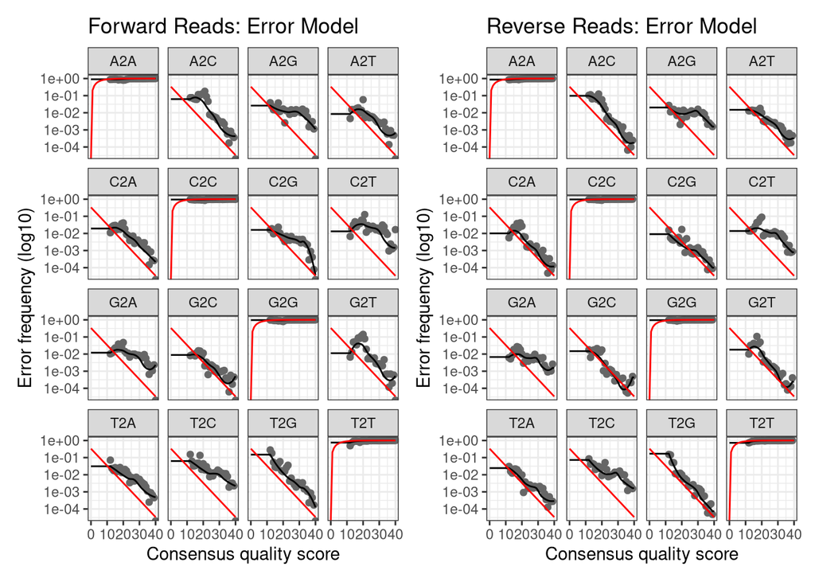

```r
# Reverse Error Plot
reverse_error_plot <-
  plotErrors(error_reverse_reads, nominalQ = TRUE) +
  labs(title = "Reverse Reads: Error Model")

# Look at the plots together
forward_error_plot + reverse_error_plot
```

```r
# Infer ASVs on the forward sequences
dada_forward <-
  dada(filtered_forward_reads,
       err = error_forward_reads,
       multithread = n_threads)
```

```
## Sample 1 - 51926 reads in 7357 unique sequences.
## Sample 2 - 58649 reads in 7861 unique sequences.
## Sample 3 - 47320 reads in 8933 unique sequences.
## Sample 4 - 65176 reads in 10060 unique sequences.
## Sample 5 - 59742 reads in 10117 unique sequences.
## Sample 6 - 54280 reads in 11654 unique sequences.
## Sample 7 - 93757 reads in 20421 unique sequences.
## Sample 8 - 76287 reads in 21664 unique sequences.
## Sample 9 - 62313 reads in 16629 unique sequences.
## Sample 10 - 69001 reads in 17017 unique sequences.
## Sample 11 - 43878 reads in 9351 unique sequences.
## Sample 12 - 66678 reads in 17161 unique sequences.
## Sample 13 - 64214 reads in 16416 unique sequences.
## Sample 14 - 72038 reads in 17764 unique sequences.
## Sample 15 - 45866 reads in 10798 unique sequences.
## Sample 16 - 87550 reads in 18382 unique sequences.
## Sample 17 - 53087 reads in 11280 unique sequences.
## Sample 18 - 72861 reads in 16914 unique sequences.
## Sample 19 - 66599 reads in 17002 unique sequences.
## Sample 20 - 56975 reads in 13871 unique sequences.
## Sample 21 - 81291 reads in 17699 unique sequences.
## Sample 22 - 52251 reads in 13609 unique sequences.
## Sample 23 - 49981 reads in 11481 unique sequences.
## Sample 24 - 58171 reads in 10234 unique sequences.
## Sample 25 - 79426 reads in 11527 unique sequences.
## Sample 26 - 45310 reads in 10510 unique sequences.
## Sample 27 - 53040 reads in 14042 unique sequences.
## Sample 28 - 62513 reads in 16435 unique sequences.
## Sample 29 - 56511 reads in 10461 unique sequences.
## Sample 30 - 55322 reads in 7639 unique sequences.
## Sample 31 - 70592 reads in 11599 unique sequences.
## Sample 32 - 54948 reads in 9013 unique sequences.
## Sample 33 - 40041 reads in 7282 unique sequences.
## Sample 34 - 47771 reads in 8557 unique sequences.
## Sample 35 - 49325 reads in 7543 unique sequences.
## Sample 36 - 45554 reads in 7644 unique sequences.
## Sample 37 - 60913 reads in 15958 unique sequences.
## Sample 38 - 51347 reads in 11808 unique sequences.
## Sample 39 - 53429 reads in 13252 unique sequences.
## Sample 40 - 77661 reads in 17805 unique sequences.
```

[output cut: 47 more lines]

```
## Sample 88 - 48199 reads in 7782 unique sequences.
## Sample 89 - 56183 reads in 10876 unique sequences.
## Sample 90 - 56087 reads in 11236 unique sequences.
## Sample 91 - 49696 reads in 9692 unique sequences.
## Sample 92 - 68679 reads in 12721 unique sequences.
## Sample 93 - 42418 reads in 7672 unique sequences.
## Sample 94 - 42882 reads in 9760 unique sequences.
## Sample 95 - 45907 reads in 12508 unique sequences.
## Sample 96 - 49141 reads in 13123 unique sequences.
## Sample 97 - 57939 reads in 13100 unique sequences.
## Sample 98 - 55550 reads in 14355 unique sequences.
## Sample 99 - 54905 reads in 11175 unique sequences.
## Sample 100 - 54795 reads in 13746 unique sequences.
## Sample 101 - 54859 reads in 11708 unique sequences.
## Sample 102 - 72199 reads in 14005 unique sequences.
```

```r
typeof(dada_forward) # It's a list
```

```
## [1] "list"
```

```r
length(dada_forward) # 102 total?
```

```
## [1] 102
```

```r
dada_forward$`20210602-MA-CES1F_R1_filtered.fastq.gz`
```

```r
dada_reverse <-
  dada(filtered_reverse_reads,
       err = error_reverse_reads ,
       multithread = n_threads)
```

```
## Sample 1 - 51926 reads in 7899 unique sequences.
## Sample 2 - 58649 reads in 7593 unique sequences.
## Sample 3 - 47320 reads in 9085 unique sequences.
## Sample 4 - 65176 reads in 9724 unique sequences.
## Sample 5 - 59742 reads in 10704 unique sequences.
## Sample 6 - 54280 reads in 11458 unique sequences.
## Sample 7 - 93757 reads in 18750 unique sequences.
## Sample 8 - 76287 reads in 19117 unique sequences.
## Sample 9 - 62313 reads in 14393 unique sequences.
## Sample 10 - 69001 reads in 15266 unique sequences.
## Sample 11 - 43878 reads in 9504 unique sequences.
## Sample 12 - 66678 reads in 15182 unique sequences.
## Sample 13 - 64214 reads in 14945 unique sequences.
## Sample 14 - 72038 reads in 15345 unique sequences.
## Sample 15 - 45866 reads in 10644 unique sequences.
## Sample 16 - 87550 reads in 16781 unique sequences.
## Sample 17 - 53087 reads in 10948 unique sequences.
## Sample 18 - 72861 reads in 15163 unique sequences.
## Sample 19 - 66599 reads in 15195 unique sequences.
## Sample 20 - 56975 reads in 12523 unique sequences.
## Sample 21 - 81291 reads in 15842 unique sequences.
## Sample 22 - 52251 reads in 12704 unique sequences.
## Sample 23 - 49981 reads in 11199 unique sequences.
## Sample 24 - 58171 reads in 10905 unique sequences.
## Sample 25 - 79426 reads in 12561 unique sequences.
## Sample 26 - 45310 reads in 10062 unique sequences.
## Sample 27 - 53040 reads in 12890 unique sequences.
## Sample 28 - 62513 reads in 14771 unique sequences.
## Sample 29 - 56511 reads in 10088 unique sequences.
## Sample 30 - 55322 reads in 7652 unique sequences.
## Sample 31 - 70592 reads in 12298 unique sequences.
## Sample 32 - 54948 reads in 9317 unique sequences.
## Sample 33 - 40041 reads in 8034 unique sequences.
## Sample 34 - 47771 reads in 8525 unique sequences.
## Sample 35 - 49325 reads in 8168 unique sequences.
## Sample 36 - 45554 reads in 8849 unique sequences.
## Sample 37 - 60913 reads in 15479 unique sequences.
## Sample 38 - 51347 reads in 11995 unique sequences.
## Sample 39 - 53429 reads in 13874 unique sequences.
## Sample 40 - 77661 reads in 15827 unique sequences.
```

[output cut: 47 more lines]

```
## Sample 88 - 48199 reads in 8453 unique sequences.
## Sample 89 - 56183 reads in 10997 unique sequences.
## Sample 90 - 56087 reads in 10989 unique sequences.
## Sample 91 - 49696 reads in 10492 unique sequences.
## Sample 92 - 68679 reads in 12723 unique sequences.
## Sample 93 - 42418 reads in 7654 unique sequences.
## Sample 94 - 42882 reads in 9093 unique sequences.
## Sample 95 - 45907 reads in 11556 unique sequences.
## Sample 96 - 49141 reads in 12964 unique sequences.
## Sample 97 - 57939 reads in 13197 unique sequences.
## Sample 98 - 55550 reads in 13045 unique sequences.
## Sample 99 - 54905 reads in 10669 unique sequences.
## Sample 100 - 54795 reads in 13385 unique sequences.
## Sample 101 - 54859 reads in 11773 unique sequences.
## Sample 102 - 72199 reads in 14467 unique sequences.
```

```r
dada_reverse[30]
```

```
## $SRR29920128_R2_filtered.fastq.gz
## dada-class: object describing DADA2 denoising results
## 145 sequence variants were inferred from 7652 input unique sequences.
## Key parameters: OMEGA_A = 1e-40, OMEGA_C = 1e-40, BAND_SIZE = 16
```

```r
length(dada_reverse) # 102 total?
```

```
## [1] 102
```

```r
merged_ASVs <-
  mergePairs(dada_forward, filtered_forward_reads,
             dada_reverse, filtered_reverse_reads,
             verbose = TRUE)
```

```
## 49926 paired-reads (in 242 unique pairings) successfully merged out of 51357 (in 810 pairings) input.
```

```
## 56853 paired-reads (in 264 unique pairings) successfully merged out of 58173 (in 718 pairings) input.
```

```
## 43732 paired-reads (in 312 unique pairings) successfully merged out of 46193 (in 1298 pairings) input.
```

```
## 61755 paired-reads (in 349 unique pairings) successfully merged out of 64157 (in 1282 pairings) input.
```

```
## 55936 paired-reads (in 333 unique pairings) successfully merged out of 58835 (in 1306 pairings) input.
```

```
## 50336 paired-reads (in 464 unique pairings) successfully merged out of 53193 (in 1643 pairings) input.
```

```
## 85402 paired-reads (in 799 unique pairings) successfully merged out of 91744 (in 3352 pairings) input.
```

```
## 64664 paired-reads (in 870 unique pairings) successfully merged out of 73782 (in 4622 pairings) input.
```

```
## 54353 paired-reads (in 666 unique pairings) successfully merged out of 60272 (in 3227 pairings) input.
```

```
## 62767 paired-reads (in 598 unique pairings) successfully merged out of 67278 (in 2735 pairings) input.
```

```
## 40126 paired-reads (in 382 unique pairings) successfully merged out of 42822 (in 1493 pairings) input.
```

```
## 58788 paired-reads (in 657 unique pairings) successfully merged out of 64679 (in 3178 pairings) input.
```

```
## 56487 paired-reads (in 631 unique pairings) successfully merged out of 62289 (in 3022 pairings) input.
```

```
## 64240 paired-reads (in 721 unique pairings) successfully merged out of 69999 (in 3009 pairings) input.
```

```
## 40536 paired-reads (in 480 unique pairings) successfully merged out of 44553 (in 2141 pairings) input.
```

```
## 80261 paired-reads (in 810 unique pairings) successfully merged out of 85764 (in 2965 pairings) input.
```

```
## 48648 paired-reads (in 531 unique pairings) successfully merged out of 51905 (in 1838 pairings) input.
```

```
## 65916 paired-reads (in 674 unique pairings) successfully merged out of 71026 (in 2824 pairings) input.
```

```
## 59161 paired-reads (in 625 unique pairings) successfully merged out of 64741 (in 2821 pairings) input.
```

```
## 51397 paired-reads (in 512 unique pairings) successfully merged out of 55554 (in 2193 pairings) input.
```

```
## 75040 paired-reads (in 704 unique pairings) successfully merged out of 79784 (in 2426 pairings) input.
```

```
## 45346 paired-reads (in 614 unique pairings) successfully merged out of 50589 (in 2899 pairings) input.
```

```
## 44877 paired-reads (in 481 unique pairings) successfully merged out of 48688 (in 1999 pairings) input.
```

```
## 54416 paired-reads (in 407 unique pairings) successfully merged out of 57152 (in 1403 pairings) input.
```

```
## 76093 paired-reads (in 393 unique pairings) successfully merged out of 78461 (in 1288 pairings) input.
```

```
## 40964 paired-reads (in 382 unique pairings) successfully merged out of 44201 (in 1751 pairings) input.
```

```
## 45813 paired-reads (in 542 unique pairings) successfully merged out of 51126 (in 2831 pairings) input.
```

```
## 55465 paired-reads (in 630 unique pairings) successfully merged out of 60665 (in 2934 pairings) input.
```

```
## 52976 paired-reads (in 355 unique pairings) successfully merged out of 55550 (in 1360 pairings) input.
```

```
## 53759 paired-reads (in 225 unique pairings) successfully merged out of 54798 (in 617 pairings) input.
```

```
## 66147 paired-reads (in 383 unique pairings) successfully merged out of 69513 (in 1450 pairings) input.
```

```
## 51596 paired-reads (in 378 unique pairings) successfully merged out of 53862 (in 1189 pairings) input.
```

```
## 37346 paired-reads (in 247 unique pairings) successfully merged out of 39313 (in 1081 pairings) input.
```

```
## 44851 paired-reads (in 306 unique pairings) successfully merged out of 46933 (in 1102 pairings) input.
```

```
## 46920 paired-reads (in 257 unique pairings) successfully merged out of 48597 (in 877 pairings) input.
```

```
## 42766 paired-reads (in 239 unique pairings) successfully merged out of 44716 (in 938 pairings) input.
```

```
## 52507 paired-reads (in 601 unique pairings) successfully merged out of 58757 (in 3314 pairings) input.
```

```
## 46563 paired-reads (in 487 unique pairings) successfully merged out of 50084 (in 1885 pairings) input.
```

```
## 47403 paired-reads (in 540 unique pairings) successfully merged out of 52013 (in 2401 pairings) input.
```

```
## 69643 paired-reads (in 755 unique pairings) successfully merged out of 75822 (in 3170 pairings) input.
```

```
## 62486 paired-reads (in 662 unique pairings) successfully merged out of 67448 (in 2608 pairings) input.
```

```
## 61655 paired-reads (in 747 unique pairings) successfully merged out of 67295 (in 3109 pairings) input.
```

```
## 41603 paired-reads (in 347 unique pairings) successfully merged out of 43906 (in 1271 pairings) input.
```

```
## 33921 paired-reads (in 207 unique pairings) successfully merged out of 35663 (in 870 pairings) input.
```

```
## 45737 paired-reads (in 583 unique pairings) successfully merged out of 50657 (in 2644 pairings) input.
```

```
## 69745 paired-reads (in 749 unique pairings) successfully merged out of 76275 (in 3281 pairings) input.
```

```
## 45470 paired-reads (in 581 unique pairings) successfully merged out of 50851 (in 2792 pairings) input.
```

```
## 50647 paired-reads (in 705 unique pairings) successfully merged out of 56786 (in 3319 pairings) input.
```

```
## 56979 paired-reads (in 197 unique pairings) successfully merged out of 58371 (in 614 pairings) input.
```

```
## 54969 paired-reads (in 194 unique pairings) successfully merged out of 56134 (in 625 pairings) input.
```

```
## 29636 paired-reads (in 231 unique pairings) successfully merged out of 31366 (in 807 pairings) input.
```

```
## 34053 paired-reads (in 205 unique pairings) successfully merged out of 35414 (in 736 pairings) input.
```

```
## 40719 paired-reads (in 378 unique pairings) successfully merged out of 44576 (in 1864 pairings) input.
```

```
## 36353 paired-reads (in 405 unique pairings) successfully merged out of 40083 (in 1936 pairings) input.
```

```
## 36837 paired-reads (in 444 unique pairings) successfully merged out of 40008 (in 1765 pairings) input.
```

```
## 52305 paired-reads (in 231 unique pairings) successfully merged out of 54507 (in 915 pairings) input.
```

```
## 54492 paired-reads (in 433 unique pairings) successfully merged out of 58734 (in 2088 pairings) input.
```

```
## 59903 paired-reads (in 492 unique pairings) successfully merged out of 63838 (in 2096 pairings) input.
```

```
## 54240 paired-reads (in 253 unique pairings) successfully merged out of 56061 (in 920 pairings) input.
```

```
## 61662 paired-reads (in 501 unique pairings) successfully merged out of 65157 (in 1955 pairings) input.
```

```
## 38942 paired-reads (in 345 unique pairings) successfully merged out of 41547 (in 1507 pairings) input.
```

```
## 39904 paired-reads (in 487 unique pairings) successfully merged out of 43798 (in 2139 pairings) input.
```

```
## 44285 paired-reads (in 478 unique pairings) successfully merged out of 48615 (in 2482 pairings) input.
```

```
## 61269 paired-reads (in 717 unique pairings) successfully merged out of 66371 (in 2875 pairings) input.
```

```
## 48647 paired-reads (in 501 unique pairings) successfully merged out of 52200 (in 2032 pairings) input.
```

```
## 34437 paired-reads (in 505 unique pairings) successfully merged out of 38177 (in 2171 pairings) input.
```

```
## 57678 paired-reads (in 724 unique pairings) successfully merged out of 62456 (in 2750 pairings) input.
```

```
## 31278 paired-reads (in 472 unique pairings) successfully merged out of 35306 (in 2071 pairings) input.
```

```
## 37033 paired-reads (in 472 unique pairings) successfully merged out of 41065 (in 2146 pairings) input.
```

```
## 59238 paired-reads (in 712 unique pairings) successfully merged out of 65068 (in 3175 pairings) input.
```

```
## 48640 paired-reads (in 577 unique pairings) successfully merged out of 52949 (in 2364 pairings) input.
```

```
## 42192 paired-reads (in 450 unique pairings) successfully merged out of 45527 (in 1776 pairings) input.
```

```
## 46647 paired-reads (in 624 unique pairings) successfully merged out of 51888 (in 2857 pairings) input.
```

```
## 47050 paired-reads (in 230 unique pairings) successfully merged out of 48854 (in 955 pairings) input.
```

```
## 46420 paired-reads (in 258 unique pairings) successfully merged out of 47912 (in 974 pairings) input.
```

```
## 29970 paired-reads (in 485 unique pairings) successfully merged out of 35310 (in 2889 pairings) input.
```

```
## 43982 paired-reads (in 556 unique pairings) successfully merged out of 48930 (in 2652 pairings) input.
```

```
## 41113 paired-reads (in 526 unique pairings) successfully merged out of 46139 (in 2695 pairings) input.
```

```
## 32223 paired-reads (in 213 unique pairings) successfully merged out of 33811 (in 847 pairings) input.
```

```
## 34005 paired-reads (in 358 unique pairings) successfully merged out of 36648 (in 1530 pairings) input.
```

```
## 42666 paired-reads (in 278 unique pairings) successfully merged out of 44764 (in 1150 pairings) input.
```

```
## 53461 paired-reads (in 313 unique pairings) successfully merged out of 55797 (in 1273 pairings) input.
```

```
## 34726 paired-reads (in 452 unique pairings) successfully merged out of 39028 (in 2384 pairings) input.
```

```
## 77959 paired-reads (in 293 unique pairings) successfully merged out of 80252 (in 927 pairings) input.
```

```
## 48512 paired-reads (in 155 unique pairings) successfully merged out of 49238 (in 395 pairings) input.
```

```
## 41745 paired-reads (in 279 unique pairings) successfully merged out of 43331 (in 912 pairings) input.
```

```
## 43116 paired-reads (in 263 unique pairings) successfully merged out of 45034 (in 867 pairings) input.
```

```
## 45734 paired-reads (in 238 unique pairings) successfully merged out of 47511 (in 900 pairings) input.
```

```
## 51714 paired-reads (in 376 unique pairings) successfully merged out of 55076 (in 1694 pairings) input.
```

```
## 51078 paired-reads (in 447 unique pairings) successfully merged out of 54834 (in 1794 pairings) input.
```

```
## 45751 paired-reads (in 432 unique pairings) successfully merged out of 48623 (in 1557 pairings) input.
```

```
## 63195 paired-reads (in 550 unique pairings) successfully merged out of 67427 (in 2034 pairings) input.
```

```
## 39223 paired-reads (in 327 unique pairings) successfully merged out of 41640 (in 1160 pairings) input.
```

```
## 38624 paired-reads (in 422 unique pairings) successfully merged out of 41609 (in 1635 pairings) input.
```

```
## 40170 paired-reads (in 559 unique pairings) successfully merged out of 44388 (in 2282 pairings) input.
```

```
## 42594 paired-reads (in 593 unique pairings) successfully merged out of 47422 (in 2713 pairings) input.
```

```
## 51910 paired-reads (in 545 unique pairings) successfully merged out of 56500 (in 2352 pairings) input.
```

```
## 48861 paired-reads (in 556 unique pairings) successfully merged out of 53697 (in 2687 pairings) input.
```

```
## 50891 paired-reads (in 366 unique pairings) successfully merged out of 53773 (in 1547 pairings) input.
```

```
## 48363 paired-reads (in 580 unique pairings) successfully merged out of 53098 (in 2749 pairings) input.
```

```
## 50515 paired-reads (in 386 unique pairings) successfully merged out of 53696 (in 1664 pairings) input.
```

```
## 67172 paired-reads (in 459 unique pairings) successfully merged out of 70961 (in 2037 pairings) input.
```

```r
typeof(merged_ASVs) # A list
```

```
## [1] "list"
```

```r
length(merged_ASVs)
```

```
## [1] 102
```

```r
head(names(merged_ASVs))
```

```
## [1] "SRR29920099_R1_filtered.fastq.gz" "SRR29920100_R1_filtered.fastq.gz"
## [3] "SRR29920101_R1_filtered.fastq.gz" "SRR29920102_R1_filtered.fastq.gz"
## [5] "SRR29920103_R1_filtered.fastq.gz" "SRR29920104_R1_filtered.fastq.gz"
```

```r
glimpse(merged_ASVs$`20210602-MA-CEB1W_R1_filtered.fastq.gz`)
```

```r
raw_ASV_table <- makeSequenceTable(merged_ASVs)

# Intuition Check: Type and dimensions of the data
dim(raw_ASV_table)
```

```
## [1]   102 10284
```

```r
typeof(raw_ASV_table)
```

```
## [1] "integer"
```

```r
write.table(raw_ASV_table, file = "/local/workdir/yz3272/BIOMI6300_IronMicrobiotaProject/02_AssignASVs/raw_ASV_counts.tsv",
            sep = "\t", quote = FALSE, col.names = NA)
```

```r
# ASV length
maxLength_ASV <- max(nchar(getSequences(raw_ASV_table)))
minLength_ASV <- min(nchar(getSequences(raw_ASV_table)))
meanLength_ASV <- mean(nchar(getSequences(raw_ASV_table)))
meanLength_ASV
```

```
## [1] 294.8725
```

```r
medianLength_ASV <- median(nchar(getSequences(raw_ASV_table)))
medianLength_ASV
```

```
## [1] 295
```

```r
# Create a table to Inspect the distribution of sequence lengths of all ASVs in dataset
table(nchar(getSequences(raw_ASV_table)))
```

```
##
##  212  222  240  284  286  287  288  289  290  291  292  293  294  295  296  297
##    1    1    1   11   29    6    5    9  466  809  431 1585 1665  745  873 1876
##  298  299  300  301  302  303  304  306  315  330
## 1123  300  252   77    6    3    6    2    1    1
```

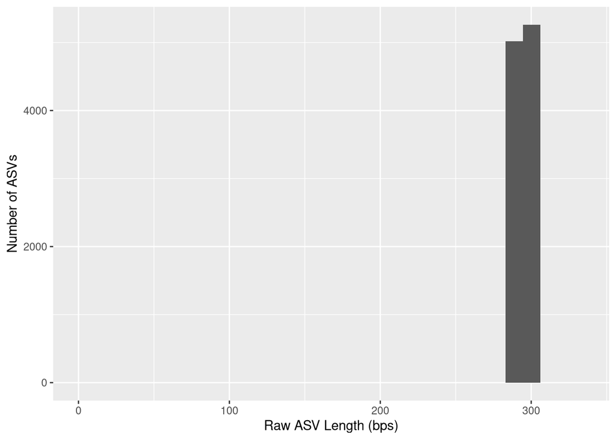

```r
# Inspect the distribution of sequence lengths of all ASVs in data set
# AFTER TRIM
plot_ASVLength_raw <-
  data.frame(Seq_Length = nchar(getSequences(raw_ASV_table))) %>%
  ggplot(aes(x = Seq_Length )) +
  geom_histogram() +
  # include the x-axis scales
  scale_x_continuous(limits = c(0, maxLength_ASV + 5)) +
  labs(y = "Number of ASVs", x = "Raw ASV Length (bps)")

# Show the plot
plot_ASVLength_raw
```

# Interpretation 1: This project used 16s rRNA seuqencing with MiSeq250, targeting the V5-V6 region using primer sets: P609D 5′-GGMTTAGATACCCBDGTA- 3′ and P699R 5′-GGGTYKCGCTCGTTR- 3’. Based on these information, estimated ASV bp length was estimated using the webtool SILVA testprobe function. The reverse primer target the 1099bp position on E.Coli’s gene, and the forward primer target at position 784. Thus, the anticipated sequenced length with this primer is 315bps, without the primers, the inserts will be 282 bps. During the trimming and turnication, only primer legnths were cut (33bps), and truncation further removed 2bps on the forward end and 15 bps on the reverse tail, thus, a total of 450bps in R1R2 after trimming. The insert size of 282bps indicated there is sufficient overlapped region (60% of total insert) and I can recover the whole insert of 282 bp in merged ASV.

# Interpretation 2:

The observed mean/median merge ASV length is 295bps, which is 13 bps longer than our expectation, suggesting that the expected amplicon length based on nominal E. coli primer coordinates may be underestimating the true amplified region or it’s possible that taxon-specific length variation was present here. Or, it can be insufficient trimming of primers, for which I went back to the fastqc rmd and redid the primer serach in filtered reads and found the sequences were clean indeed, with the following statements seen:

[1] “Forward primer remains in 0 % of filtered forward sequences” [1] “Reverse primer remains in 0 % of filtered reverse sequences”

Thus, given the fact that the insert size was estimated in SILVA testprobe, the dataset is suggesting the real insert size is ~295bps.

# Interpretation 3:

```r
# Subset only ASVs that are 295 bps long
raw_ASV_table_trimmed <-
  raw_ASV_table[, nchar(colnames(raw_ASV_table)) >= 290 &
                    nchar(colnames(raw_ASV_table)) <= 300]

# Inspect the distribution of sequence lengths of all ASVs in dataset
table(nchar(getSequences(raw_ASV_table_trimmed)))
```

```
##
##  290  291  292  293  294  295  296  297  298  299  300
##  466  809  431 1585 1665  745  873 1876 1123  300  252
```

```r
# What proportion of total ASV sequences are left in the data?
percRetained_Trimmed <- sum(raw_ASV_table_trimmed)/sum(raw_ASV_table)
percRetained_Trimmed
```

```
## [1] 0.9961031
```

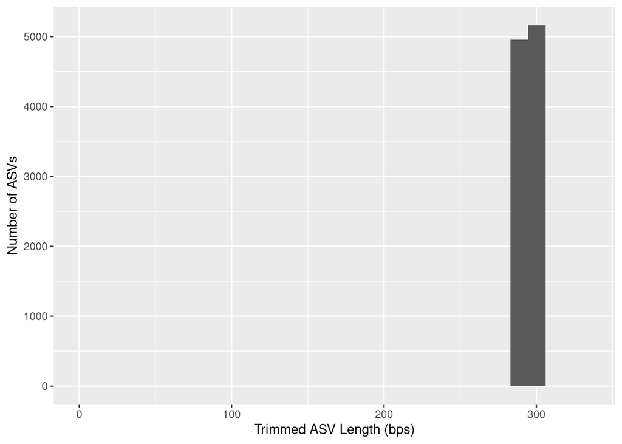

```r
plot_ASVLength_trimmed <-
  data.frame(Seq_Length = nchar(getSequences(raw_ASV_table_trimmed))) %>%
  ggplot(aes(x = Seq_Length )) +
  geom_histogram() +
  # include the x-axis scales
  scale_x_continuous(limits = c(0, maxLength_ASV + 5)) +
  labs(y = "Number of ASVs", x = "Trimmed ASV Length (bps)")

# Show the plot
plot_ASVLength_trimmed
```

```r
# Remove the chimeras in the raw ASV table
noChimeras_ASV_table <-
  removeBimeraDenovo(raw_ASV_table_trimmed,
                     method="consensus",
                     multithread = n_threads,
                     verbose=TRUE)
```

```
## Identified 8534 bimeras out of 10125 input sequences.
```

```r
dim(noChimeras_ASV_table)
```

```
## [1]  102 1591
```

```r
# What proportion is left of the sequences?
# Chimera removal compared to trimming
percRetained_chimerasTrimmed <- sum(noChimeras_ASV_table)/sum(raw_ASV_table_trimmed)
percRetained_chimerasTrimmed
```

```
## [1] 0.7314651
```

```r
# Chimera removal compared to raw
percRetained_chimerasRaw <-sum(noChimeras_ASV_table)/sum(raw_ASV_table)
percRetained_chimerasRaw
```

```
## [1] 0.7286146
```

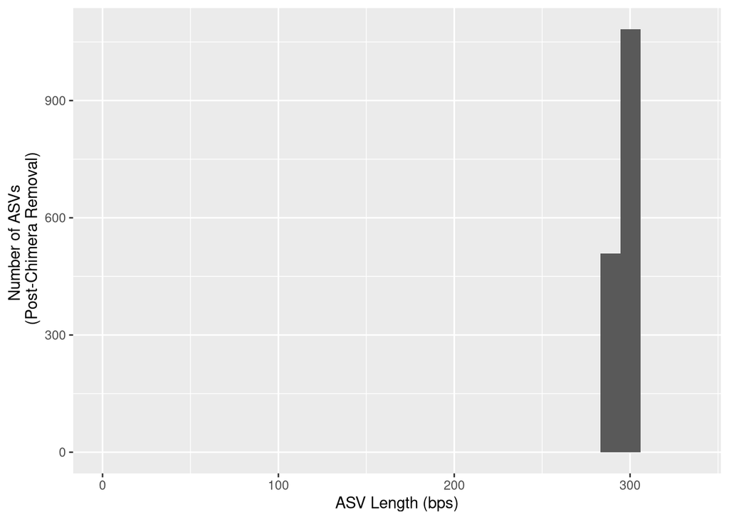

```r
# Plot it
plot_ASVLength_NoChimeras <-
  data.frame(Seq_Length_NoChim = nchar(getSequences(noChimeras_ASV_table))) %>%
  ggplot(aes(x = Seq_Length_NoChim )) +
  geom_histogram()+
  # include the x-axis scales
  scale_x_continuous(limits = c(0, maxLength_ASV + 5)) +
  labs(y = "Number of ASVs \n (Post-Chimera Removal)",
       x = "ASV Length (bps)")

# Show the plot
plot_ASVLength_NoChimeras
```

# Interpretation 4:

Chimera removal identified a large proportion of sequence variants (~84%) as bimeric; however, these were low-abundance ASVs. Approximately 73% of total reads were retained after chimera removal, indicating that the majority of sequence abundance was preserved and suggesting effective removal of spurious variants without substantial loss of biological signal.

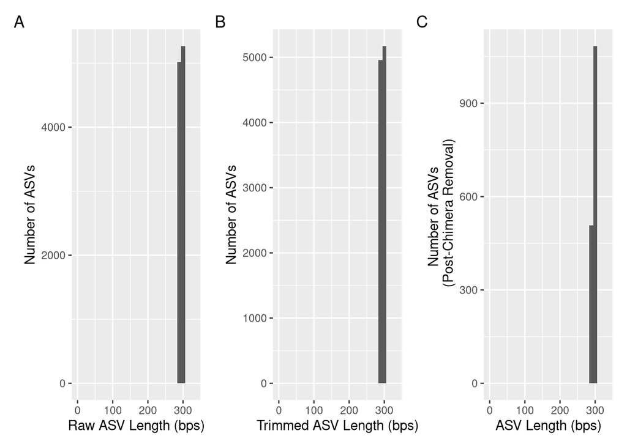

```r
plot_ASVLength_raw + plot_ASVLength_trimmed + plot_ASVLength_NoChimeras +
    plot_annotation(tag_levels = 'A')
```

```r
# A little function to identify number seqs
getN <- function(x) sum(getUniques(x))

# Make the table to track the seqs
track <- cbind(sapply(dada_forward, getN),
               sapply(dada_reverse, getN),
               sapply(merged_ASVs, getN),
               rowSums(noChimeras_ASV_table))

head(track)
```

```
##                                   [,1]  [,2]  [,3]  [,4]
## SRR29920099_R1_filtered.fastq.gz 51517 51721 49926 42560
## SRR29920100_R1_filtered.fastq.gz 58321 58468 56853 40601
## SRR29920101_R1_filtered.fastq.gz 46523 46900 43732 35469
## SRR29920102_R1_filtered.fastq.gz 64397 64903 61755 44925
## SRR29920103_R1_filtered.fastq.gz 59118 59385 55936 43217
## SRR29920104_R1_filtered.fastq.gz 53516 53894 50336 36595
```

```r
# Update column names to be more informative (most are missing at the moment!)
colnames(track) <- c("denoisedF", "denoisedR", "merged", "nochim")
rownames(track) <- row.names(noChimeras_ASV_table)

# Generate a dataframe to track the reads through our DADA2 pipeline
track_counts_df <-
  track %>%
  # make it a dataframe
  as.data.frame() %>%
  rownames_to_column(var = "sample_names")

# Now let's add a column for the number of ASVs
# First, intuition check that the samples match
stopifnot(track_counts_df$sample_names == row.names(noChimeras_ASV_table))

# Now, let's add a new column with the number of ASVs
track_counts_df <-
  track_counts_df %>%
  mutate(num_ASVs = rowSums(noChimeras_ASV_table > 1))

# Visualize it in table format
DT::datatable(track_counts_df)
```

|  | sample_names | denoisedF | denoisedR | merged | nochim | num_ASVs |
| --- | --- | --- | --- | --- | --- | --- |
| 1 | SRR29920099_R1_filtered.fastq.gz | 51517 | 51721 | 49926 | 42560 | 67 |
| 2 | SRR29920100_R1_filtered.fastq.gz | 58321 | 58468 | 56853 | 40601 | 56 |
| 3 | SRR29920101_R1_filtered.fastq.gz | 46523 | 46900 | 43732 | 35469 | 105 |
| 4 | SRR29920102_R1_filtered.fastq.gz | 64397 | 64903 | 61755 | 44925 | 92 |
| 5 | SRR29920103_R1_filtered.fastq.gz | 59118 | 59385 | 55936 | 43217 | 81 |
| 6 | SRR29920104_R1_filtered.fastq.gz | 53516 | 53894 | 50336 | 36595 | 105 |
| 7 | SRR29920105_R1_filtered.fastq.gz | 92281 | 93064 | 85402 | 60561 | 160 |
| 8 | SRR29920106_R1_filtered.fastq.gz | 74367 | 75587 | 64664 | 46720 | 205 |
| 9 | SRR29920107_R1_filtered.fastq.gz | 60769 | 61687 | 54353 | 37441 | 157 |
| 10 | SRR29920108_R1_filtered.fastq.gz | 67699 | 68457 | 62767 | 47213 | 195 |

[output cut: 92 more lines]

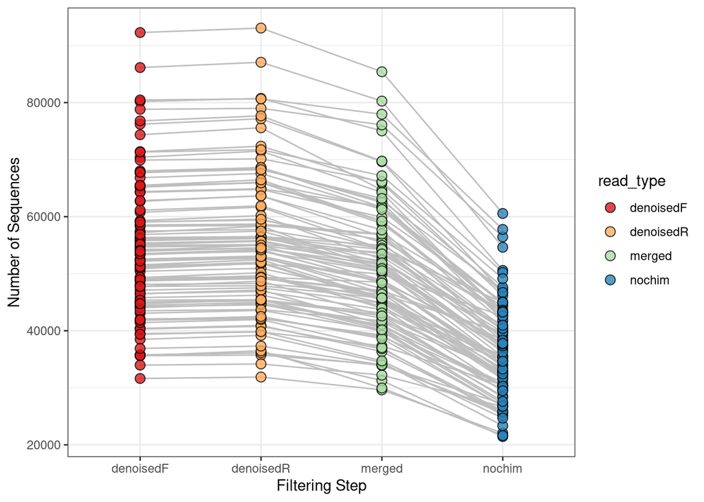

```r
# Plot it!
track_counts_df %>%
  pivot_longer(denoisedF:nochim, names_to = "read_type", values_to = "num_reads") %>%
  mutate(read_type = fct_relevel(read_type, "denoisedF", "denoisedR", "merged", "nochim")) %>%
  ggplot(aes(x = read_type, y = num_reads, fill = read_type)) +
  geom_line(aes(group = sample_names), color = "grey") +
  geom_point(shape = 21, size = 3, alpha = 0.8) +
  scale_fill_brewer(palette = "Spectral") +
  labs(x = "Filtering Step", y = "Number of Sequences") +
  theme_bw()
```

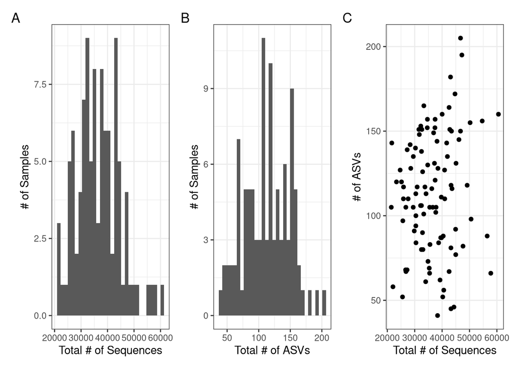

```r
plot_ReadDepth <-
  track_counts_df %>%
  ggplot(aes(x = nochim)) +
  geom_histogram() +
  labs(x = "Total # of Sequences", y = "# of Samples") +
  theme_bw()

# What is the ASV richness per sample?
plot_ASVRichness <-
  track_counts_df %>%
  ggplot(aes(x = num_ASVs)) +
  geom_histogram() +
  labs(x = "Total # of ASVs", y = "# of Samples") +
  theme_bw()

# Now, let's look at the relationship of ASVs and Sequencing depth
plot_ReadDepth_ASVRichness <-
  track_counts_df %>%
  ggplot(aes(x = nochim, y = num_ASVs)) +
  geom_point() +
  labs(x = "Total # of Sequences", y = "# of ASVs") +
  theme_bw()

# Show the plots together
plot_ReadDepth + plot_ASVRichness + plot_ReadDepth_ASVRichness +
    plot_annotation(tag_levels = 'A')
```

# Interpretation 5: Sequencing depth across samples ranged from approximately 20,000 to 60,000 reads, with most samples clustering between 30,000 and 45,000 reads, so there is likely sufficient coverage for downstream analysis. ASV richness plot showed that the majority of samples containing between 100 and 150 ASVs, suggesting moderate microbial diversity and consistent denoising performance. A weak positive relationship between sequencing depth and ASV richness was observed. These results suggest the suitability of the dataset for downstream analyses, although appropriate normalization/rarefraction shall be applied to account for variation in sequencing depth.

```r
# Assign up to genus level
taxa_train <-
  assignTaxonomy(noChimeras_ASV_table,
                 refFasta = "/workdir/in_class_data/taxonomy/silva_nr99_v138.2_toGenus_trainset.fa.gz",
                 multithread = n_threads)

# Add the genus/species information
taxa_addSpecies <-
  addSpecies(taxa_train,
              refFasta = "/workdir/in_class_data/taxonomy/silva_v138.2_assignSpecies.fa.gz")

# Inspect the taxonomy
glimpse(taxa_addSpecies)
```

```
##  chr [1:1591, 1:7] "Bacteria" "Bacteria" "Bacteria" "Bacteria" "Bacteria" ...
##  - attr(*, "dimnames")=List of 2
##   ..$ : chr [1:1591] "GTCCACGCCGTAAACGATGAGGACCAAGTGTTGGGGGTGAAACCTCAGTGCTGAAGTTAACGCAGTGAGTCCTCCGCCTGGGGAGTATGCACGCAAGTGTGAAACTCAAAG"| __truncated__ "GTCCATGCCGTAAACGATGAGTGCTAAGTGTTGGGAGGTTTCCGCCTCTCAGTGCTGCAGCTAACGCATTAAGCACTCCGCCTGGGGAGTACGACCGCAAGGTTGAAACTC"| __truncated__ "GTCCTAGCCGTAAACGA…
##   ..$ : chr [1:7] "Kingdom" "Phylum" "Class" "Order" ...
```

```r
# Let's removing the ASV sequence rownames for display only
taxa_print <- taxa_addSpecies
rownames(taxa_print) <- NULL
head(taxa_print)
```

```
##      Kingdom    Phylum           Class            Order
## [1,] "Bacteria" "Bacillota"      "Bacilli"        "Erysipelotrichales"
## [2,] "Bacteria" "Bacillota"      "Bacilli"        "Lactobacillales"
## [3,] "Bacteria" "Actinomycetota" "Coriobacteriia" "Coriobacteriales"
## [4,] "Bacteria" "Actinomycetota" "Actinobacteria" "Bifidobacteriales"
## [5,] "Bacteria" "Bacteroidota"   "Bacteroidia"    "Bacteroidales"
## [6,] "Bacteria" "Bacillota"      "Bacilli"        "Lactobacillales"
##      Family                Genus                       Species
## [1,] "Erysipelotrichaceae" "Faecalibaculum"            "rodentium"
## [2,] "Lactobacillaceae"    NA                          NA
## [3,] "Atopobiaceae"        "Coriobacteriaceae UCG-002" NA
## [4,] "Bifidobacteriaceae"  "Bifidobacterium"           "pseudolongum"
## [5,] "Bacteroidaceae"      "Bacteroides"               "dorei"
## [6,] "Lactobacillaceae"    "Ligilactobacillus"         NA
```

```r
# we need to transpose the matrix
final_ASV_table_withSeqs <- t(noChimeras_ASV_table)
# Intuition check
head(rownames(final_ASV_table_withSeqs)) # ASV Sequences
```

```
## [1] "GTCCACGCCGTAAACGATGAGGACCAAGTGTTGGGGGTGAAACCTCAGTGCTGAAGTTAA…"
## [2] "GTCCATGCCGTAAACGATGAGTGCTAAGTGTTGGGAGGTTTCCGCCTCTCAGTGCTGCAG…"
## [3] "GTCCTAGCCGTAAACGATGGACGCTAGGTGTGGGGCGATGTCGCTCCGTGCCGCAGCTAA…"
## [4] "GTCCACGCCGTAAACGGTGGATGCTGGATGTGGGGCCCTTTTTCCGGGTCCTGTGTCGGA…"
## [5] "GTCCACACGGTAAACGATGAATACTCGCTGTTTGCGATATACGGCAAGCGGCCAAGCGAA…"
## [6] "GTCCACGCCGTAAACGATGAATGCTAAGTGTTGGAGGGTTTCCGCCCTTCAGTGCTGCAG…"
```

```r
head(colnames(final_ASV_table_withSeqs))
```

```
## [1] "SRR29920099_R1_filtered.fastq.gz" "SRR29920100_R1_filtered.fastq.gz"
## [3] "SRR29920101_R1_filtered.fastq.gz" "SRR29920102_R1_filtered.fastq.gz"
## [5] "SRR29920103_R1_filtered.fastq.gz" "SRR29920104_R1_filtered.fastq.gz"
```

```r
head(sample_names)
```

```
## [1] "SRR29920099" "SRR29920100" "SRR29920101" "SRR29920102" "SRR29920103"
## [6] "SRR29920104"
```

```r
head(colnames(final_ASV_table_withSeqs)) # Sample names
```

```
## [1] "SRR29920099_R1_filtered.fastq.gz" "SRR29920100_R1_filtered.fastq.gz"
## [3] "SRR29920101_R1_filtered.fastq.gz" "SRR29920102_R1_filtered.fastq.gz"
## [5] "SRR29920103_R1_filtered.fastq.gz" "SRR29920104_R1_filtered.fastq.gz"
```

```r
head(sapply(strsplit(colnames(final_ASV_table_withSeqs), "_"), `[`,1)) # Looks good!
```

```
## [1] "SRR29920099" "SRR29920100" "SRR29920101" "SRR29920102" "SRR29920103"
## [6] "SRR29920104"
```

```r
# Now, add a break in the script break if this isn't true!
# Let's make sure the sample names match the file names in the matrix.
stopifnot(sapply(strsplit(colnames(final_ASV_table_withSeqs), "_"), `[`,1) == sample_names)

# Now, we've done some checks to prove to ourselves there will be no silent errors,
# Let's rename!
colnames(final_ASV_table_withSeqs) <- sample_names
head(colnames(final_ASV_table_withSeqs))
```

```
## [1] "SRR29920099" "SRR29920100" "SRR29920101" "SRR29920102" "SRR29920103"
## [6] "SRR29920104"
```

```r
# Give headers more manageable names
# First pull the ASV sequences from the rownames
ASV_seqs <- rownames(final_ASV_table_withSeqs)
ASV_seqs[1:5]
```

```
## [1] "GTCCACGCCGTAAACGATGAGGACCAAGTGTTGGGGGTGAAACCTCAGTGCTGAAGTTAA…"
## [2] "GTCCATGCCGTAAACGATGAGTGCTAAGTGTTGGGAGGTTTCCGCCTCTCAGTGCTGCAG…"
## [3] "GTCCTAGCCGTAAACGATGGACGCTAGGTGTGGGGCGATGTCGCTCCGTGCCGCAGCTAA…"
## [4] "GTCCACGCCGTAAACGGTGGATGCTGGATGTGGGGCCCTTTTTCCGGGTCCTGTGTCGGA…"
## [5] "GTCCACACGGTAAACGATGAATACTCGCTGTTTGCGATATACGGCAAGCGGCCAAGCGAA…"
```

```r
# How many ASVs?
num_ASVs <- dim(final_ASV_table_withSeqs)[1] # select the number of rows
num_ASVs
```

```
## [1] 1591
```

```r
# Make an empty vector the length of the number of ASVs,
# which is where we will place the new operational ASV names
ASV_headers <- vector(num_ASVs, mode = "character")

# Let's mae sure we have an empty vector!
ASV_headers[1:5]
```

```
## [1] "" "" "" "" ""
```

```r
length(ASV_headers)
```

```
## [1] 1591
```

```r
# loop through vector and fill it in with ASV names
for (i in 1:num_ASVs) {
  # Add leading zero to ASV name so they print in correct order.
  ASV_number <- sprintf("%04d", i)
  # Now, rename each spot in the ASV header vector as we loop through the for loop
  ASV_headers[i] <- paste(">ASV", ASV_number, sep = "_")
}

# Intuition check
ASV_headers[1:5]
```

```
## [1] ">ASV_0001" ">ASV_0002" ">ASV_0003" ">ASV_0004" ">ASV_0005"
```

```r
# Create a new ASV table, which will have the ASV numbers as names
# View(noChimeras_ASV_table) # To view the table
final_ASV_table <- final_ASV_table_withSeqs
glimpse(final_ASV_table)
```

```
##  int [1:1591, 1:102] 29068 0 0 1934 317 754 2228 0 0 0 ...
##  - attr(*, "dimnames")=List of 2
##   ..$ : chr [1:1591] "GTCCACGCCGTAAACGATGAGGACCAAGTGTTGGGGGTGAAACCTCAGTGCTGAAGTTAACGCAGTGAGTCCTCCGCCTGGGGAGTATGCACGCAAGTGTGAAACTCAAAG"| __truncated__ "GTCCATGCCGTAAACGATGAGTGCTAAGTGTTGGGAGGTTTCCGCCTCTCAGTGCTGCAGCTAACGCATTAAGCACTCCGCCTGGGGAGTACGACCGCAAGGTTGAAACTC"| __truncated__ "GTCCTAGCCGTAAACGA…
##   ..$ : chr [1:102] "SRR29920099" "SRR29920100" "SRR29920101" "SRR29920102" ...
```

```r
## Replace the ASV seqs with the ASV numbers
row.names(final_ASV_table) <- sub(">", "", ASV_headers)
final_ASV_table[1:5, 1:5]
```

```
##          SRR29920099 SRR29920100 SRR29920101 SRR29920102 SRR29920103
## ASV_0001       29068       11227       19023       14247       21513
## ASV_0002           0       20864           0       20083           0
## ASV_0003           0           0           0           0           0
## ASV_0004        1934          13         568           4        1645
## ASV_0005         317           0         893           0         385
```

```r
# 1. Write count table with ASV sequence names
write.table(final_ASV_table_withSeqs,
            file = "/local/workdir/yz3272/BIOMI6300_IronMicrobiotaProject/02_AssignASVs/ASV_table_withSeqNames.tsv",
            sep = "\t", quote = FALSE, col.names = NA)

# 2. Write count table with ASV numbered names (e.g. ASV_1, ASV_2, etc)
write.table(final_ASV_table,
            file = "/local/workdir/yz3272/BIOMI6300_IronMicrobiotaProject/02_AssignASVs/ASV_table.tsv",
            sep = "\t", quote = FALSE, col.names = NA)

# Combine in a fasta format with the cbind() function
ASV_fasta <- c(rbind(ASV_headers, ASV_seqs))
head(ASV_fasta, n = 4)
```

```
## [1] ">ASV_0001"
## [2] "GTCCACGCCGTAAACGATGAGGACCAAGTGTTGGGGGTGAAACCTCAGTGCTGAAGTTAA…"
## [3] ">ASV_0002"
## [4] "GTCCATGCCGTAAACGATGAGTGCTAAGTGTTGGGAGGTTTCCGCCTCTCAGTGCTGCAG…"
```

```r
# Then, let's write it to a fasta file!
# This will be our reference later on for which seq matches which ASV
write(ASV_fasta, "/local/workdir/yz3272/BIOMI6300_IronMicrobiotaProject/02_AssignASVs/ASVs.fasta")
```

```r
dim(taxa_addSpecies)
```

```
## [1] 1591    7
```

```r
colnames(taxa_addSpecies)
```

```
## [1] "Kingdom" "Phylum"  "Class"   "Order"   "Family"  "Genus"   "Species"
```

```r
head(rownames(taxa_addSpecies), n = 2)
```

```
## [1] "GTCCACGCCGTAAACGATGAGGACCAAGTGTTGGGGGTGAAACCTCAGTGCTGAAGTTAA…"
## [2] "GTCCATGCCGTAAACGATGAGTGCTAAGTGTTGGGAGGTTTCCGCCTCTCAGTGCTGCAG…"
```

```r
class(taxa_addSpecies)
```

```
## [1] "matrix" "array"
```

```r
##### Prepare tax table
# 1. Add the ASV sequences from the rownames to a column
new_tax_table <-
  taxa_addSpecies%>%
  as.data.frame() %>%
  rownames_to_column(var = "ASVseqs")

# Intuition check
glimpse(new_tax_table)
```

```
## Rows: 1,591
## Columns: 8
## $ ASVseqs <chr> "GTCCACGCCGTAAACGATGAGGACCAAGTGTTGGGGGTGAAACCTCAGTGCTGAAGTTAAC…
## $ Kingdom <chr> "Bacteria", "Bacteria", "Bacteria", "Bacteria", "Bacteria", "B…
## $ Phylum  <chr> "Bacillota", "Bacillota", "Actinomycetota", "Actinomycetota", …
## $ Class   <chr> "Bacilli", "Bacilli", "Coriobacteriia", "Actinobacteria", "Bac…
## $ Order   <chr> "Erysipelotrichales", "Lactobacillales", "Coriobacteriales", "…
## $ Family  <chr> "Erysipelotrichaceae", "Lactobacillaceae", "Atopobiaceae", "Bi…
## $ Genus   <chr> "Faecalibaculum", NA, "Coriobacteriaceae UCG-002", "Bifidobact…
## $ Species <chr> "rodentium", NA, NA, "pseudolongum", "dorei", NA, NA, "vulgatu…
```

```r
# IMPORTANT! Let's do our intuition check
# This is where we ensure we don't mix up the ASV names!
stopifnot(new_tax_table$ASVseqs == rownames(final_ASV_table_withSeqs))

# Now let's add the ASV names
rownames(new_tax_table) <- rownames(final_ASV_table)
head(new_tax_table)
```

```
##                                                                                                                                                                                                                                                                                                          …
## ASV_0001         GTCCACGCCGTAAACGATGAGGACCAAGTGTTGGGGGTGAAACCTCAGTGCTGAAGTTAA…
## ASV_0002 GTCCATGCCGTAAACGATGAGTGCTAAGTGTTGGGAGGTTTCCGCCTCTCAGTGCTGCAG…
## ASV_0003         GTCCTAGCCGTAAACGATGGACGCTAGGTGTGGGGCGATGTCGCTCCGTGCCGCAGCTAA…
## ASV_0004 GTCCACGCCGTAAACGGTGGATGCTGGATGTGGGGCCCTTTTTCCGGGTCCTGTGTCGGA…
## ASV_0005      GTCCACACGGTAAACGATGAATACTCGCTGTTTGCGATATACGGCAAGCGGCCAAGCGAA…
## ASV_0006 GTCCACGCCGTAAACGATGAATGCTAAGTGTTGGAGGGTTTCCGCCCTTCAGTGCTGCAG…
##           Kingdom         Phylum          Class              Order
## ASV_0001 Bacteria      Bacillota        Bacilli Erysipelotrichales
## ASV_0002 Bacteria      Bacillota        Bacilli    Lactobacillales
## ASV_0003 Bacteria Actinomycetota Coriobacteriia   Coriobacteriales
## ASV_0004 Bacteria Actinomycetota Actinobacteria  Bifidobacteriales
## ASV_0005 Bacteria   Bacteroidota    Bacteroidia      Bacteroidales
## ASV_0006 Bacteria      Bacillota        Bacilli    Lactobacillales
##                       Family                     Genus      Species
## ASV_0001 Erysipelotrichaceae            Faecalibaculum    rodentium
## ASV_0002    Lactobacillaceae                      <NA>         <NA>
## ASV_0003        Atopobiaceae Coriobacteriaceae UCG-002         <NA>
## ASV_0004  Bifidobacteriaceae           Bifidobacterium pseudolongum
## ASV_0005      Bacteroidaceae               Bacteroides        dorei
## ASV_0006    Lactobacillaceae         Ligilactobacillus         <NA>
```

```r
ASV_tax_table <-
  new_tax_table %>%
  # add rownames from count table for phyloseq handoff
  mutate(ASV = rownames(final_ASV_table)) %>%
  # Reorder the columns
  dplyr::select(Kingdom, Phylum, Class, Order, Family, Genus, Species, ASV, ASVseqs)

# Assign the rownames, which is required by phyloseq
rownames(ASV_tax_table) <- ASV_tax_table$ASV

# Take a quick look
glimpse(ASV_tax_table)
```

```
## Rows: 1,591
## Columns: 9
## $ Kingdom <chr> "Bacteria", "Bacteria", "Bacteria", "Bacteria", "Bacteria", "B…
## $ Phylum  <chr> "Bacillota", "Bacillota", "Actinomycetota", "Actinomycetota", …
## $ Class   <chr> "Bacilli", "Bacilli", "Coriobacteriia", "Actinobacteria", "Bac…
## $ Order   <chr> "Erysipelotrichales", "Lactobacillales", "Coriobacteriales", "…
## $ Family  <chr> "Erysipelotrichaceae", "Lactobacillaceae", "Atopobiaceae", "Bi…
## $ Genus   <chr> "Faecalibaculum", NA, "Coriobacteriaceae UCG-002", "Bifidobact…
## $ Species <chr> "rodentium", NA, NA, "pseudolongum", "dorei", NA, NA, "vulgatu…
## $ ASV     <chr> "ASV_0001", "ASV_0002", "ASV_0003", "ASV_0004", "ASV_0005", "A…
## $ ASVseqs <chr> "GTCCACGCCGTAAACGATGAGGACCAAGTGTTGGGGGTGAAACCTCAGTGCTGAAGTTAAC…
```

```r
# Intution check
stopifnot(ASV_tax_table$ASV == rownames(ASV_tax_table),
          rownames(ASV_tax_table) == rownames(ASV_tax_table))

# Write the table
write.table(ASV_tax_table,
            file = "/local/workdir/yz3272/BIOMI6300_IronMicrobiotaProject/02_AssignASVs/ASV_taxonomy.tsv",
            sep = "\t", quote = FALSE, col.names = NA)
```

```r
# And save the track_counts_df a R object, which we will merge with metadata information in the next step of the analysis in nalysis/02_Taxonomic_Assignment.
save(track_counts_df, file = "/local/workdir/yz3272/BIOMI6300_IronMicrobiotaProject/02_AssignASVs/track_read_counts.RData")
```

```r
metadata_physeq <- read.csv("/local/workdir/yz3272/BIOMI6300_IronMicrobiotaProject/metadata.csv")
```

```r
# Construct the phyloseq object
raw_physeq <- phyloseq(otu_table(final_ASV_table, taxa_are_rows = TRUE),
                       # The taxonomy table needs to first be converted into a matrix
                       tax_table(as.matrix(ASV_tax_table)),
                       # Next, add the sample_data
                       metadata_physeq)

# Check the phyloseq object!
raw_physeq
```

```
## phyloseq-class experiment-level object
## otu_table()   OTU Table:         [ 1591 taxa and 102 samples ]
## tax_table()   Taxonomy Table:    [ 1591 taxa by 9 taxonomic ranks ]
```

```r
# Now, save the phyloseq object, but use the correct path to your folder:
save(raw_physeq, file = "/local/workdir/yz3272/BIOMI6300_IronMicrobiotaProject/02_AssignASVs/raw_physeq.RData")
```

```r
# Take the time now that we are at the end of the script
end_time <- Sys.time()
end_time
```

```
## [1] "2026-04-09 13:14:51 EDT"
```

```r
# Echo the elapsed time
elapsed_time <- round((end_time - start_time), 3)
elapsed_time
```

```
## Time difference of 19.3 mins
```